# Assignment 8.3

Scott Breitbach

7/20/2020

## Assignment 8.3: Clustering

```r
clusterDF <- read_csv("completed/Week8/data/clustering-data.csv")
head(clusterDF)
```

```
## # A tibble: 6 x 2
##       x     y
##   <dbl> <dbl>
## 1    46   236
## 2    69   236
## 3   144   236
## 4   171   236
## 5   194   236
## 6   195   236
```

```r
summary(clusterDF)
```

```
##        x               y
##  Min.   :  0.0   Min.   :134.0
##  1st Qu.: 56.0   1st Qu.:141.0
##  Median : 82.0   Median :154.0
##  Mean   :109.6   Mean   :175.7
##  3rd Qu.:180.0   3rd Qu.:218.0
##  Max.   :249.0   Max.   :236.0
```

### a. Plot the dataset using a scatter plot.

[figure not shown]

```r
ggplot(data = clusterDF, mapping = aes(x, y)) + geom_point()
```

### b. Fit the dataset using the k-means algorithm from k=2 to k=12. Create a scatter plot of the resultant clusters for each value of k.

[figure not shown]

```r
clusters.2 <- kmeans(clusterDF, 2)
clusterDF$k2 <- as.factor(clusters.2$cluster)

ggplot(clusterDF, mapping = aes(x, y, color = k2)) + geom_point()
```

[figure not shown]

```r
clusters.3 <- kmeans(clusterDF, 3)
clusterDF$k3 <- as.factor(clusters.3$cluster)

ggplot(clusterDF, mapping = aes(x, y, color = k3)) + geom_point()
```

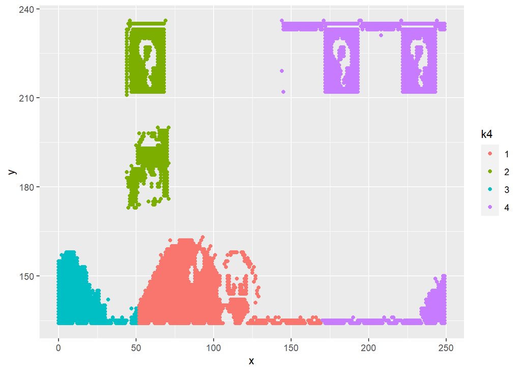

```r
clusters.4 <- kmeans(clusterDF, 4)
clusterDF$k4 <- as.factor(clusters.4$cluster)

ggplot(clusterDF, mapping = aes(x, y, color = k4)) + geom_point()
```

[figure not shown]

```r
clusters.5 <- kmeans(clusterDF, 5)
clusterDF$k5 <- as.factor(clusters.5$cluster)

ggplot(clusterDF, mapping = aes(x, y, color = k5)) + geom_point()
```

[figure not shown]

```r
clusters.6 <- kmeans(clusterDF, 6)
clusterDF$k6 <- as.factor(clusters.6$cluster)

ggplot(clusterDF, mapping = aes(x, y, color = k6)) + geom_point()
```

[figure not shown]

```r
clusters.7 <- kmeans(clusterDF, 7)
clusterDF$k7 <- as.factor(clusters.7$cluster)

ggplot(clusterDF, mapping = aes(x, y, color = k7)) + geom_point()
```

[figure not shown]

```r
clusters.8 <- kmeans(clusterDF, 8)
clusterDF$k8 <- as.factor(clusters.8$cluster)

ggplot(clusterDF, mapping = aes(x, y, color = k8)) + geom_point()
```

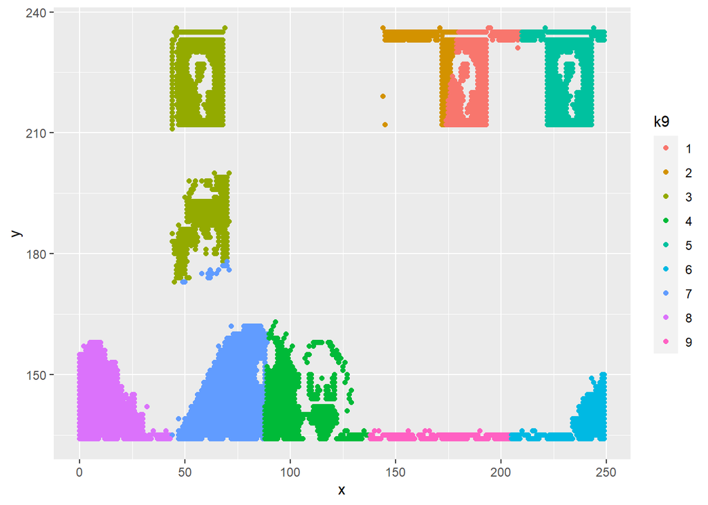

```r
clusters.9 <- kmeans(clusterDF, 9)
clusterDF$k9 <- as.factor(clusters.9$cluster)

ggplot(clusterDF, mapping = aes(x, y, color = k9)) + geom_point()
```

[figure not shown]

```r
clusters.10 <- kmeans(clusterDF, 10)
clusterDF$k10 <- as.factor(clusters.10$cluster)

ggplot(clusterDF, mapping = aes(x, y, color = k10)) + geom_point()
```

[figure not shown]

```r
clusters.11 <- kmeans(clusterDF, 11)
clusterDF$k11 <- as.factor(clusters.11$cluster)

ggplot(clusterDF, mapping = aes(x, y, color = k11)) + geom_point()
```

[figure not shown]

```r
clusters.12 <- kmeans(clusterDF, 12)
clusterDF$k12 <- as.factor(clusters.12$cluster)

ggplot(clusterDF, mapping = aes(x, y, color = k12)) + geom_point()
```

### c. To calculate the average distance from the center of each cluster, compute the distance of each data point to the center of the cluster it is assigned to and take the average value of all of those distances.

```r
myDist<-function(p1,p2) sqrt((p1[,1]-p2[,1])^2+(p1[,2]-p2[,2])^2)
```

```r
# Get distances from each cluster
dist.1 <- myDist(clusterDF[clusters.2$cluster==1,],clusters.2$centers[1,,drop=FALSE])
dist.2 <- myDist(clusterDF[clusters.2$cluster==2,],clusters.2$centers[2,,drop=FALSE])
# Get average distance
k2.avdist <- sum(dist.1, dist.2)/nrow(clusterDF)
k2.avdist
```

```
## [1] 42.07717
```

```r
# Get distances from each cluster
dist.1 <- myDist(clusterDF[clusters.3$cluster==1,],clusters.3$centers[1,,drop=FALSE])
dist.2 <- myDist(clusterDF[clusters.3$cluster==2,],clusters.3$centers[2,,drop=FALSE])
dist.3 <- myDist(clusterDF[clusters.3$cluster==3,],clusters.3$centers[3,,drop=FALSE])
# Get average distance
k3.avdist <- sum(dist.1, dist.2, dist.3)/nrow(clusterDF)
k3.avdist
```

```
## [1] 36.53193
```

```r
# Get distances from each cluster
dist.1 <- myDist(clusterDF[clusters.4$cluster==1,],clusters.4$centers[1,,drop=FALSE])
dist.2 <- myDist(clusterDF[clusters.4$cluster==2,],clusters.4$centers[2,,drop=FALSE])
dist.3 <- myDist(clusterDF[clusters.4$cluster==3,],clusters.4$centers[3,,drop=FALSE])
dist.4 <- myDist(clusterDF[clusters.4$cluster==4,],clusters.4$centers[4,,drop=FALSE])
# Get average distance
k4.avdist <- sum(dist.1, dist.2, dist.3, dist.4)/nrow(clusterDF)
k4.avdist
```

```
## [1] 25.78229
```

```r
# Get distances from each cluster
dist.1 <- myDist(clusterDF[clusters.5$cluster==1,],clusters.5$centers[1,,drop=FALSE])
dist.2 <- myDist(clusterDF[clusters.5$cluster==2,],clusters.5$centers[2,,drop=FALSE])
dist.3 <- myDist(clusterDF[clusters.5$cluster==3,],clusters.5$centers[3,,drop=FALSE])
dist.4 <- myDist(clusterDF[clusters.5$cluster==4,],clusters.5$centers[4,,drop=FALSE])
dist.5 <- myDist(clusterDF[clusters.5$cluster==5,],clusters.5$centers[5,,drop=FALSE])
# Get average distance
k5.avdist <- sum(dist.1, dist.2, dist.3, dist.4, dist.5)/nrow(clusterDF)
k5.avdist
```

```
## [1] 20.33178
```

```r
# Get distances from each cluster
dist.1 <- myDist(clusterDF[clusters.6$cluster==1,],clusters.6$centers[1,,drop=FALSE])
dist.2 <- myDist(clusterDF[clusters.6$cluster==2,],clusters.6$centers[2,,drop=FALSE])
dist.3 <- myDist(clusterDF[clusters.6$cluster==3,],clusters.6$centers[3,,drop=FALSE])
dist.4 <- myDist(clusterDF[clusters.6$cluster==4,],clusters.6$centers[4,,drop=FALSE])
dist.5 <- myDist(clusterDF[clusters.6$cluster==5,],clusters.6$centers[5,,drop=FALSE])
dist.6 <- myDist(clusterDF[clusters.6$cluster==6,],clusters.6$centers[6,,drop=FALSE])
# Get average distance
k6.avdist <- sum(dist.1, dist.2, dist.3, dist.4, dist.5, dist.6)/nrow(clusterDF)
k6.avdist
```

```
## [1] 18.10784
```

```r
# Get distances from each cluster
dist.1 <- myDist(clusterDF[clusters.7$cluster==1,],clusters.7$centers[1,,drop=FALSE])
dist.2 <- myDist(clusterDF[clusters.7$cluster==2,],clusters.7$centers[2,,drop=FALSE])
dist.3 <- myDist(clusterDF[clusters.7$cluster==3,],clusters.7$centers[3,,drop=FALSE])
dist.4 <- myDist(clusterDF[clusters.7$cluster==4,],clusters.7$centers[4,,drop=FALSE])
dist.5 <- myDist(clusterDF[clusters.7$cluster==5,],clusters.7$centers[5,,drop=FALSE])
dist.6 <- myDist(clusterDF[clusters.7$cluster==6,],clusters.7$centers[6,,drop=FALSE])
dist.7 <- myDist(clusterDF[clusters.7$cluster==7,],clusters.7$centers[7,,drop=FALSE])
# Get average distance
k7.avdist <- sum(dist.1, dist.2, dist.3, dist.4, dist.5, dist.6, dist.7)/nrow(clusterDF)
k7.avdist
```

```
## [1] 14.38976
```

```r
# Get distances from each cluster
dist.1 <- myDist(clusterDF[clusters.8$cluster==1,],clusters.8$centers[1,,drop=FALSE])
dist.2 <- myDist(clusterDF[clusters.8$cluster==2,],clusters.8$centers[2,,drop=FALSE])
dist.3 <- myDist(clusterDF[clusters.8$cluster==3,],clusters.8$centers[3,,drop=FALSE])
dist.4 <- myDist(clusterDF[clusters.8$cluster==4,],clusters.8$centers[4,,drop=FALSE])
dist.5 <- myDist(clusterDF[clusters.8$cluster==5,],clusters.8$centers[5,,drop=FALSE])
dist.6 <- myDist(clusterDF[clusters.8$cluster==6,],clusters.8$centers[6,,drop=FALSE])
dist.7 <- myDist(clusterDF[clusters.8$cluster==7,],clusters.8$centers[7,,drop=FALSE])
dist.8 <- myDist(clusterDF[clusters.8$cluster==8,],clusters.8$centers[8,,drop=FALSE])
# Get average distance
k8.avdist <- sum(dist.1, dist.2, dist.3, dist.4, dist.5, dist.6, dist.7, dist.8)/nrow(clusterDF)
k8.avdist
```

```
## [1] 14.01589
```

```r
# Get distances from each cluster
dist.1 <- myDist(clusterDF[clusters.9$cluster==1,],clusters.9$centers[1,,drop=FALSE])
dist.2 <- myDist(clusterDF[clusters.9$cluster==2,],clusters.9$centers[2,,drop=FALSE])
dist.3 <- myDist(clusterDF[clusters.9$cluster==3,],clusters.9$centers[3,,drop=FALSE])
dist.4 <- myDist(clusterDF[clusters.9$cluster==4,],clusters.9$centers[4,,drop=FALSE])
dist.5 <- myDist(clusterDF[clusters.9$cluster==5,],clusters.9$centers[5,,drop=FALSE])
dist.6 <- myDist(clusterDF[clusters.9$cluster==6,],clusters.9$centers[6,,drop=FALSE])
dist.7 <- myDist(clusterDF[clusters.9$cluster==7,],clusters.9$centers[7,,drop=FALSE])
dist.8 <- myDist(clusterDF[clusters.9$cluster==8,],clusters.9$centers[8,,drop=FALSE])
dist.9 <- myDist(clusterDF[clusters.9$cluster==9,],clusters.9$centers[9,,drop=FALSE])
# Get average distance
k9.avdist <- sum(dist.1, dist.2, dist.3, dist.4, dist.5, dist.6, dist.7, dist.8, dist.9)/nrow(clusterDF)
k9.avdist
```

```
## [1] 12.82285
```

```r
# Get distances from each cluster
dist.1 <- myDist(clusterDF[clusters.10$cluster==1,],clusters.10$centers[1,,drop=FALSE])
dist.2 <- myDist(clusterDF[clusters.10$cluster==2,],clusters.10$centers[2,,drop=FALSE])
dist.3 <- myDist(clusterDF[clusters.10$cluster==3,],clusters.10$centers[3,,drop=FALSE])
dist.4 <- myDist(clusterDF[clusters.10$cluster==4,],clusters.10$centers[4,,drop=FALSE])
dist.5 <- myDist(clusterDF[clusters.10$cluster==5,],clusters.10$centers[5,,drop=FALSE])
dist.6 <- myDist(clusterDF[clusters.10$cluster==6,],clusters.10$centers[6,,drop=FALSE])
dist.7 <- myDist(clusterDF[clusters.10$cluster==7,],clusters.10$centers[7,,drop=FALSE])
dist.8 <- myDist(clusterDF[clusters.10$cluster==8,],clusters.10$centers[8,,drop=FALSE])
dist.9 <- myDist(clusterDF[clusters.10$cluster==9,],clusters.10$centers[9,,drop=FALSE])
dist.10 <- myDist(clusterDF[clusters.10$cluster==10,],clusters.10$centers[10,,drop=FALSE])
# Get average distance
k10.avdist <- sum(dist.1, dist.2, dist.3, dist.4, dist.5, dist.6, dist.7, dist.8, dist.9, dist.10)/nrow(clusterDF)
k10.avdist
```

```
## [1] 10.47212
```

```r
# Get distances from each cluster
dist.1 <- myDist(clusterDF[clusters.11$cluster==1,],clusters.11$centers[1,,drop=FALSE])
dist.2 <- myDist(clusterDF[clusters.11$cluster==2,],clusters.11$centers[2,,drop=FALSE])
dist.3 <- myDist(clusterDF[clusters.11$cluster==3,],clusters.11$centers[3,,drop=FALSE])
dist.4 <- myDist(clusterDF[clusters.11$cluster==4,],clusters.11$centers[4,,drop=FALSE])
dist.5 <- myDist(clusterDF[clusters.11$cluster==5,],clusters.11$centers[5,,drop=FALSE])
dist.6 <- myDist(clusterDF[clusters.11$cluster==6,],clusters.11$centers[6,,drop=FALSE])
dist.7 <- myDist(clusterDF[clusters.11$cluster==7,],clusters.11$centers[7,,drop=FALSE])
dist.8 <- myDist(clusterDF[clusters.11$cluster==8,],clusters.11$centers[8,,drop=FALSE])
dist.9 <- myDist(clusterDF[clusters.11$cluster==9,],clusters.11$centers[9,,drop=FALSE])
dist.10 <- myDist(clusterDF[clusters.11$cluster==10,],clusters.11$centers[10,,drop=FALSE])
dist.11 <- myDist(clusterDF[clusters.11$cluster==11,],clusters.11$centers[11,,drop=FALSE])
# Get average distance
k11.avdist <- sum(dist.1, dist.2, dist.3, dist.4, dist.5, dist.6, dist.7, dist.8, dist.9, dist.10, dist.11)/nrow(clusterDF)
k11.avdist
```

```
## [1] 10.09825
```

```r
# Get distances from each cluster
dist.1 <- myDist(clusterDF[clusters.12$cluster==1,],clusters.12$centers[1,,drop=FALSE])
dist.2 <- myDist(clusterDF[clusters.12$cluster==2,],clusters.12$centers[2,,drop=FALSE])
dist.3 <- myDist(clusterDF[clusters.12$cluster==3,],clusters.12$centers[3,,drop=FALSE])
dist.4 <- myDist(clusterDF[clusters.12$cluster==4,],clusters.12$centers[4,,drop=FALSE])
dist.5 <- myDist(clusterDF[clusters.12$cluster==5,],clusters.12$centers[5,,drop=FALSE])
dist.6 <- myDist(clusterDF[clusters.12$cluster==6,],clusters.12$centers[6,,drop=FALSE])
dist.7 <- myDist(clusterDF[clusters.12$cluster==7,],clusters.12$centers[7,,drop=FALSE])
dist.8 <- myDist(clusterDF[clusters.12$cluster==8,],clusters.12$centers[8,,drop=FALSE])
dist.9 <- myDist(clusterDF[clusters.12$cluster==9,],clusters.12$centers[9,,drop=FALSE])
dist.10 <- myDist(clusterDF[clusters.12$cluster==10,],clusters.12$centers[10,,drop=FALSE])
dist.11 <- myDist(clusterDF[clusters.12$cluster==11,],clusters.12$centers[11,,drop=FALSE])
dist.12 <- myDist(clusterDF[clusters.12$cluster==12,],clusters.12$centers[12,,drop=FALSE])
# Get average distance
k12.avdist <- sum(dist.1, dist.2, dist.3, dist.4, dist.5, dist.6, dist.7, dist.8, dist.9, dist.10, dist.11, dist.12)/nrow(clusterDF)
k12.avdist
```

```
## [1] 9.779885
```

#### Calculate this average distance from the center of each cluster for each value of k and plot it as a line chart where k is the x-axis and the average distance is the y-axis.

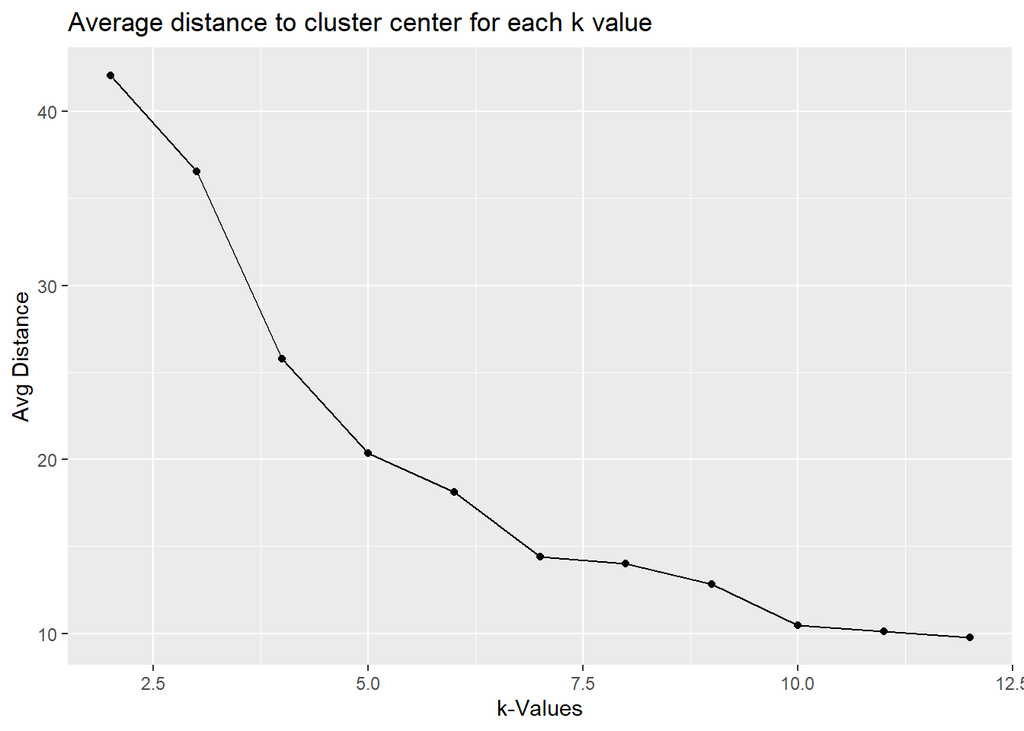

```r
k.values <- 2:12
avDist <- c(k2.avdist, k3.avdist, k4.avdist, k5.avdist, k6.avdist, k7.avdist, k8.avdist, k9.avdist, k10.avdist, k11.avdist, k12.avdist)
k.dist <- data.frame(k.values, avDist)

ggplot(k.dist, mapping = aes(k.values, avDist)) + geom_line() + geom_point() + labs(x = "k-Values", y = "Avg Distance", title = "Average distance to cluster center for each k value")
```

As a side note, I started trying to figure out a cleaner way to calculate average distance from cluster center for each value of k by using a function with a built-in loop. I wasn’t able to get it working initially and between life, work, and school I ran out of time to figure it out and implement it, but I’m sure it’s possible.